# dados sobre Covid-19 no Brasil

por Jean Prado ([@jeangprado](https://twitter.com/jeangprado))

atualizado em 04/05/2020 às 21h49

# **evolução dos casos**

*gráfico em [escala logarítmica](https://escoladedados.org/2020/04/escalas-lineares-ou-nao-lineares-por-que-nao-ambas/). últimos dados liberados pelo Ministério da Saúde em 4 de maio de 2020.

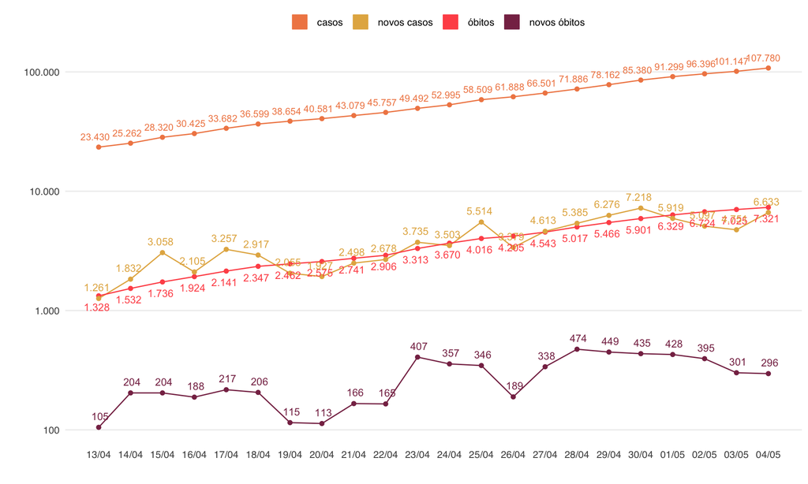

# **brasil e mundo**

**casos**: no **50º dia desde o 100º caso**, o Brasil tem **101.147 casos confirmados de Covid-19**. para comparação, os **5 países com mais casos no mundo** tinham, neste período, esse número de casos: **Estados Unidos** (825.041), **Espanha** (197.142), **Itália** (159.516), **Reino Unido** (143.464), **Alemanha** (141.672).

abaixo, a comparação entre brasil e mundo no número de casos. *gráfico em escala logarítmica. fonte: [Our World in Data](https://ourworldindata.org/coronavirus-source-data). os dados podem estar um dia ou dois atrasados porque o site demora para consolidar.

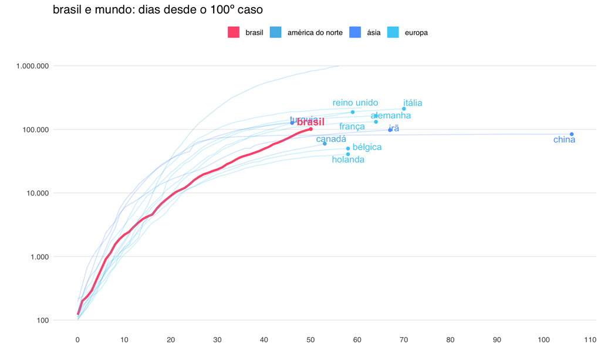

**óbitos**: no **45º dia desde o 5º óbito**, o Brasil tem **7.025 óbitos decorrentes de Covid-19**. para comparação, os **5 países com mais mortes no mundo** tinham, neste período, esse número de óbitos: **Estados Unidos** (33.284), **Reino Unido** (22.792), **Espanha** (21.282), **França** (19.718), **Itália** (18.281).

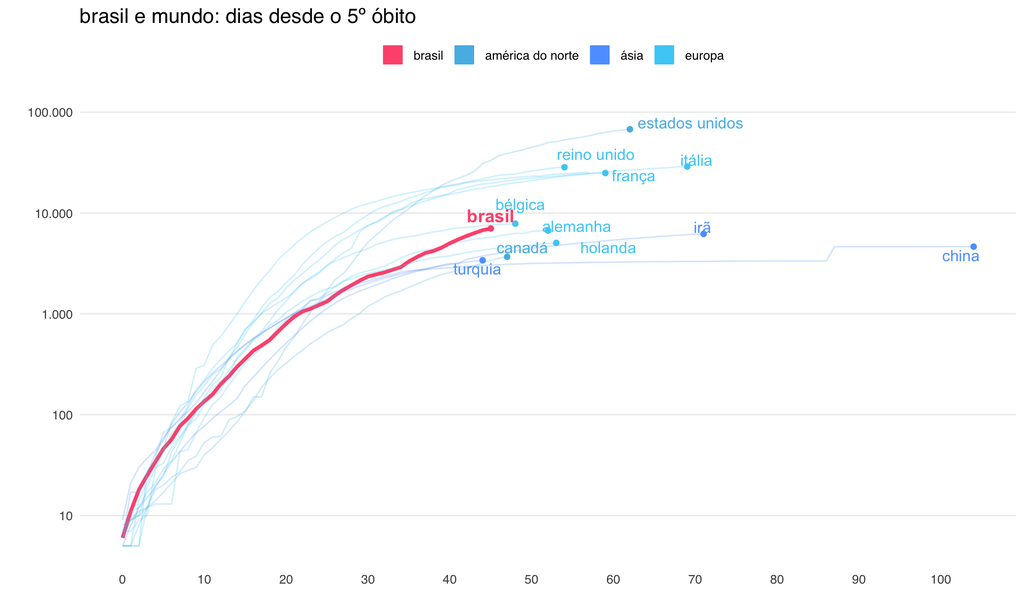

# **novos casos por estado e região**

esses gráficos focam no **crescimento diário do número de casos**, não no crescimento total. por isso, representam o número de novos casos em relação ao dia anterior.

*os gráficos de cada região estão em escalas diferentes.

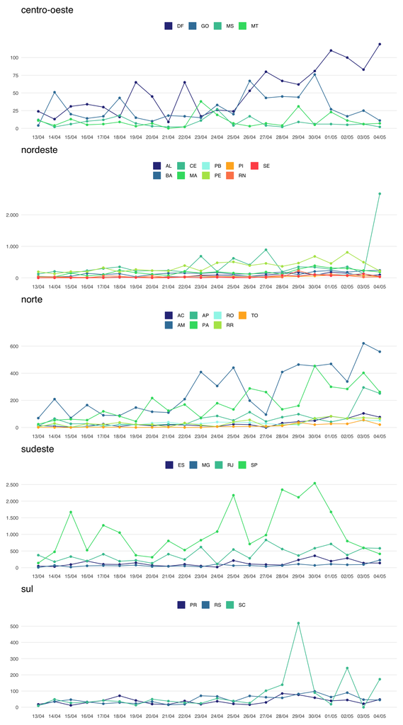

# **casos e letalidade (por região)**

[figure not shown]

# **dados mais recentes (por estado)**

aqui, sempre que o gráfico representar novos casos ou óbitos, os dados serão do último dia liberado pelo Ministério da Saúde. do contrário, os dados são cumulativos.

*cada gráfico tem sua própria escala.

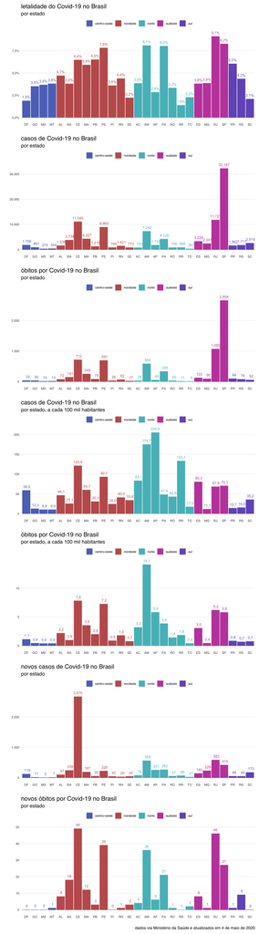